# MSDA 607 Final Project

Monu Chacko

5/6/2019

## Motivation

Should Travelers Avoid Flying Airlines That Have Had Crashes in the Past?

The data set contains crash data from many airlines. After a crash people move to other airlines for safety. Does that mean than other airlines are more safe than the airlines that crashed? We will take a look at historical data to find if there is a pattern after the crash or is it just a fear

## Obtain Data

### Data Source

Parameters  
- airline: Airline (asterisk indicates that regional subsidiaries are included)  
- avail_seat_km_per_week: Available seat kilometers flown every week  
- incidents_85_99: Total number of incidents, 1985–1999  
- fatal_accidents_85_99: Total number of fatal accidents, 1985–1999  
- fatalities_85_99: Total number of fatalities, 1985–1999  
- incidents_00_14: Total number of incidents, 2000–2014  
- fatal_accidents_00_14: Total number of fatal accidents, 2000–2014  
- fatalities_00_14: Total number of fatalities, 2000–2014

Source: https://github.com/fivethirtyeight/data/blob/master/airline-safety/airline-safety.csv

```r
library(tidyr)
library(dplyr)
library(tidyverse)
library(janitor)
library(kableExtra)
library(stringr)
library(ggplot2)
library(data.table)
library(formattable)
```

### SQL Database

Data can be normalised in relation data structure. Following is the structure of the relation data. The main detail table tblAirlinesIncident contains details of the incident and is related to master tables tblAirlines, tblIncidentTypeMst and tblYearRange using foreign key.

View SQL Queries: https://github.com/monuchacko/cuny_msds/blob/master/data_607/DATA607_FinalProject.sql

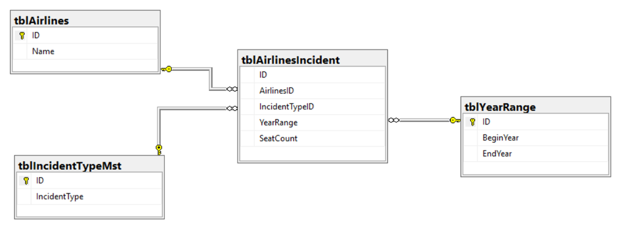

### MongoDB

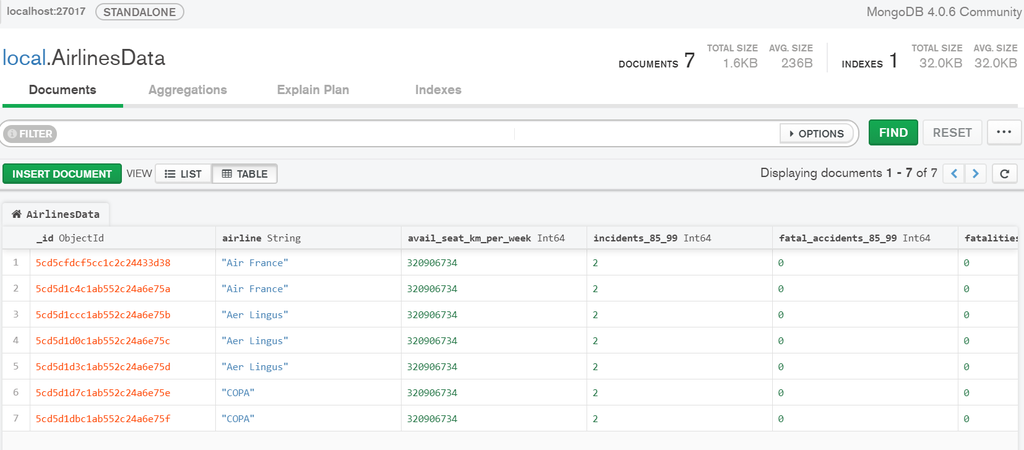

### CSV data

Data can be extracted from CSV to data frame using R packages. This data can be cleaned and transformed. In the code below we are loading data directly from the source. The data is inspected and cleaned.

```r
# Read from csv
dsAL <- read.csv(file="https://raw.githubusercontent.com/fivethirtyeight/data/master/airline-safety/airline-safety.csv", header=TRUE, sep=",", stringsAsFactors=FALSE)

# Display sample data
head(dsAL) %>% kable() %>% kable_styling()
```

| airline | avail_seat_km_per_week | incidents_85_99 | fatal_accidents_85_99 | fatalities_85_99 | incidents_00_14 | fatal_accidents_00_14 | fatalities_00_14 |
| --- | --- | --- | --- | --- | --- | --- | --- |
| Aer Lingus | 320906734 | 2 | 0 | 0 | 0 | 0 | 0 |
| Aeroflot* | 1197672318 | 76 | 14 | 128 | 6 | 1 | 88 |
| Aerolineas Argentinas | 385803648 | 6 | 0 | 0 | 1 | 0 | 0 |
| Aeromexico* | 596871813 | 3 | 1 | 64 | 5 | 0 | 0 |
| Air Canada | 1865253802 | 2 | 0 | 0 | 2 | 0 | 0 |
| Air France | 3004002661 | 14 | 4 | 79 | 6 | 2 | 337 |

## Scrub Data

### Extraction/ Transformation

```r
# Remove asterisk
dsAL$airline <- stringr::str_replace(dsAL$airline, '\\*', '')

# Use this data to populate sql master tables
# Airlines Master
airlineMst <- unique(dsAL$airline)
head(airlineMst) %>% kable() %>% kable_styling()
```

| x |
| --- |
| Aer Lingus |
| Aeroflot |
| Aerolineas Argentinas |
| Aeromexico |
| Air Canada |
| Air France |

```r
# Incident Master
incidentMst <- c("incident", "accident", "fatalities")
head(incidentMst) %>% kable() %>% kable_styling()
```

| x |
| --- |
| incident |
| accident |
| fatalities |

```r
# Year Range Master
yearRangeMst <- c("yr_85_99", "yr_00_14")

# View Data
head(yearRangeMst) %>% kable() %>% kable_styling()
```

| x |
| --- |
| yr_85_99 |
| yr_00_14 |

```r
str(dsAL)
```

```
## 'data.frame':    56 obs. of  8 variables:
##  $ airline               : chr  "Aer Lingus" "Aeroflot" "Aerolineas Argentinas" "Aeromexico" ...
##  $ avail_seat_km_per_week: num  3.21e+08 1.20e+09 3.86e+08 5.97e+08 1.87e+09 ...
##  $ incidents_85_99       : int  2 76 6 3 2 14 2 3 5 7 ...
##  $ fatal_accidents_85_99 : int  0 14 0 1 0 4 1 0 0 2 ...
##  $ fatalities_85_99      : int  0 128 0 64 0 79 329 0 0 50 ...
##  $ incidents_00_14       : int  0 6 1 5 2 6 4 5 5 4 ...
##  $ fatal_accidents_00_14 : int  0 1 0 0 0 2 1 1 1 0 ...
##  $ fatalities_00_14      : int  0 88 0 0 0 337 158 7 88 0 ...
```

```r
# Rename column names (if necessary)
names(dsAL) <- c("airline", "avail_seat_km_per_week", "incidents_85_99", "fatal_accidents_85_99", "fatalities_85_99", "incidents_00_14", "fatal_accidents_00_14", "fatalities_00_14")

# Gather Data
dsALTransform01 <- gather(dsAL, "incident", "count", incidents_85_99)
dsALTransform02 <- gather(dsAL, "incident", "count", fatal_accidents_85_99)
dsALTransform03 <- gather(dsAL, "incident", "count", fatalities_85_99)
dsALTransform04 <- gather(dsAL, "incident", "count", incidents_00_14)
dsALTransform05 <- gather(dsAL, "incident", "count", fatal_accidents_00_14)
dsALTransform06 <- gather(dsAL, "incident", "count", fatalities_00_14)

# Extract Subset
dsALTransform01 <- subset(dsALTransform01, select = c(airline,avail_seat_km_per_week,incident,count) )
dsALTransform02 <- subset(dsALTransform02, select = c(airline,avail_seat_km_per_week,incident,count) )
dsALTransform03 <- subset(dsALTransform03, select = c(airline,avail_seat_km_per_week,incident,count) )
dsALTransform04 <- subset(dsALTransform04, select = c(airline,avail_seat_km_per_week,incident,count) )
dsALTransform05 <- subset(dsALTransform05, select = c(airline,avail_seat_km_per_week,incident,count) )
dsALTransform06 <- subset(dsALTransform06, select = c(airline,avail_seat_km_per_week,incident,count) )

# View Column Names of one sample DataSet
names(dsALTransform01)
```

```
## [1] "airline"                "avail_seat_km_per_week"
## [3] "incident"               "count"
```

```r
# Combine Data into one DataSet
dsALTransformCombined <- rbind(dsALTransform01, dsALTransform02, dsALTransform03, dsALTransform04, dsALTransform05, dsALTransform06)

# Find the mean
al_seats_mean = mean(dsALTransformCombined$avail_seat_km_per_week)
al_seats_mean
```

```
## [1] 1384621305
```

```r
# Create Columns from Existing
dsALTransformCombined <- dsALTransformCombined %>%
  mutate(incident_type = ifelse(incident == "incidents_85_99", "incident", ifelse(incident == "fatal_accidents_85_99", "fatal_accident", ifelse(incident == "fatalities_85_99", "fatalities", ifelse(incident == "incidents_00_14", "incident", ifelse(incident == "fatal_accidents_00_14", "fatal_accident", ifelse(incident == "fatalities_00_14", "fatalities", ""))))))) %>%
  mutate(incident_year = ifelse(incident == "incidents_85_99", "1999", ifelse(incident == "fatal_accidents_85_99", "1999", ifelse(incident == "fatalities_85_99", "1999", ifelse(incident == "incidents_00_14", "2014", ifelse(incident == "fatal_accidents_00_14", "2014", ifelse(incident == "fatalities_00_14", "2014", ""))))))) %>%
  mutate(incident_ratio = ifelse(count == 0, round(avail_seat_km_per_week/1000000, 0), round((avail_seat_km_per_week/1000000)/count, 0) ))

head(dsALTransformCombined) %>% kable() %>% kable_styling()
```

| airline | avail_seat_km_per_week | incident | count | incident_type | incident_year | incident_ratio |
| --- | --- | --- | --- | --- | --- | --- |
| Aer Lingus | 320906734 | incidents_85_99 | 2 | incident | 1999 | 160 |
| Aeroflot | 1197672318 | incidents_85_99 | 76 | incident | 1999 | 16 |
| Aerolineas Argentinas | 385803648 | incidents_85_99 | 6 | incident | 1999 | 64 |
| Aeromexico | 596871813 | incidents_85_99 | 3 | incident | 1999 | 199 |
| Air Canada | 1865253802 | incidents_85_99 | 2 | incident | 1999 | 933 |
| Air France | 3004002661 | incidents_85_99 | 14 | incident | 1999 | 215 |

```r
al_mean = mean(dsALTransformCombined$count)
al_mean
```

```
## [1] 30.34524
```

```r
al_sd = sd(dsALTransformCombined$count)
al_sd
```

```
## [1] 85.49267
```

```r
dim(dsALTransform01)
```

```
## [1] 56  4
```

```r
dim(dsALTransformCombined)
```

```
## [1] 336   7
```

## Explore Data

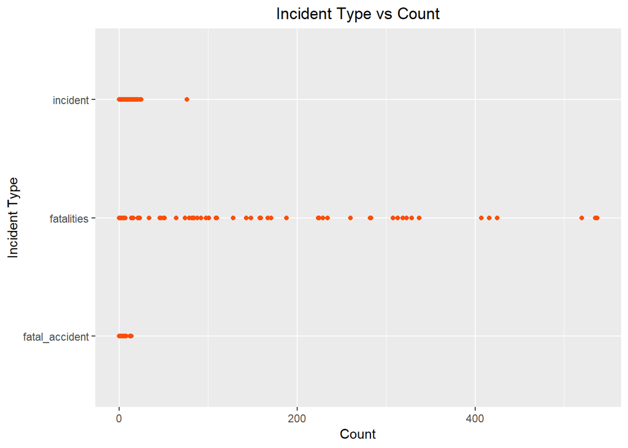

```r
ggplot(data=dsALTransformCombined, aes(x=count, y=incident_type)) + geom_point(aes(count, incident_type), color = "#FC4E07") + ylab("Incident Type") + xlab("Count") + ggtitle("Incident Type vs Count") +
  theme(plot.title = element_text(hjust = 0.5))
```

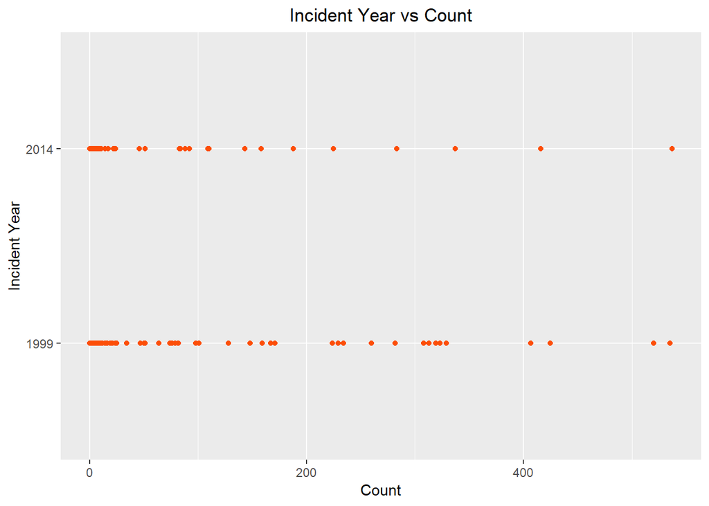

```r
ggplot(data=dsALTransformCombined, aes(x=count, y=incident_year)) + geom_point(aes(count, incident_year), color = "#FC4E07") + ylab("Incident Year") + xlab("Count") + ggtitle("Incident Year vs Count") +
  theme(plot.title = element_text(hjust = 0.5))
```

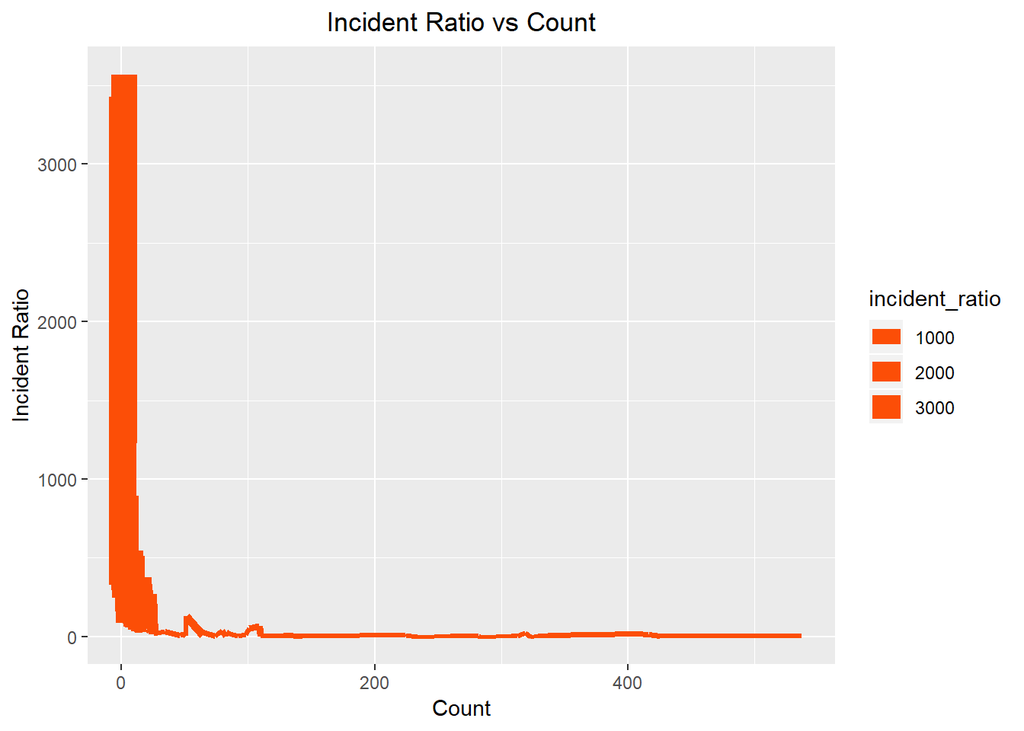

```r
ggplot(data=dsALTransformCombined, aes(x=count, y=incident_ratio)) + geom_line(aes(size=incident_ratio), color = "#FC4E07") + ylab("Incident Ratio") + xlab("Count") + ggtitle("Incident Ratio vs Count") +
  theme(plot.title = element_text(hjust = 0.5))
```

## Model Data

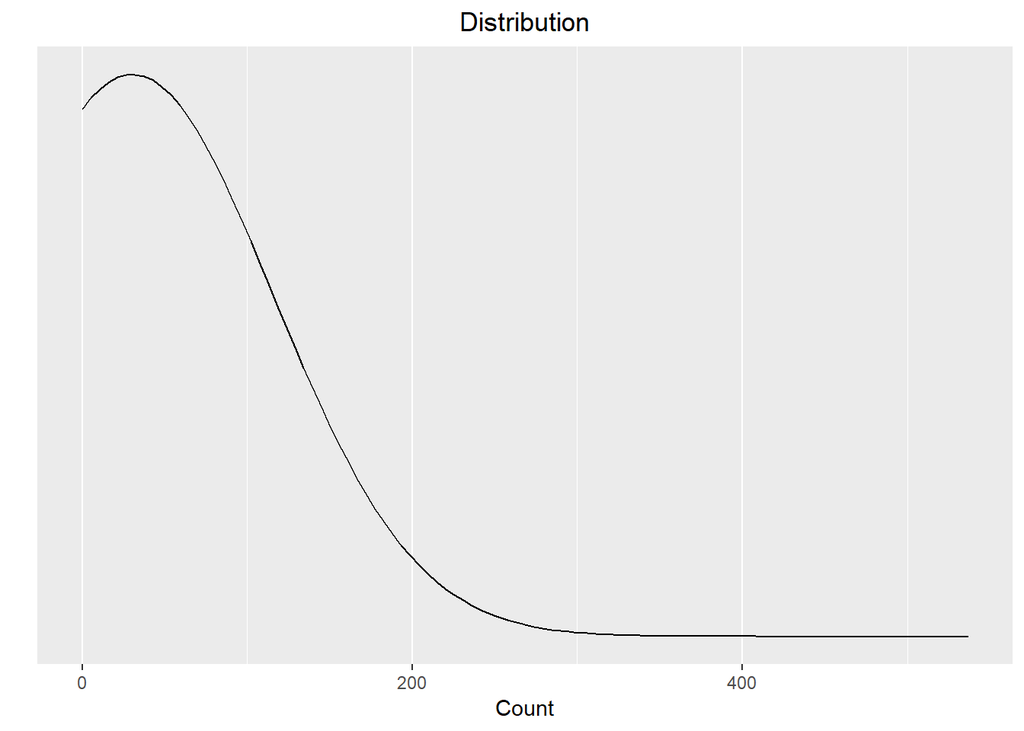

```r
#dsALTransformCombined_dnorm <- dnorm(dsALTransformCombined$count, mean=al_mean, sd=al_sd)
#plot(dsALTransformCombined$count, dsALTransformCombined_dnorm)

# Find the distribution
ggplot(data = dsALTransformCombined, aes(dsALTransformCombined$count)) +
  stat_function(fun = dnorm, n = 101, args = list(mean=al_mean, sd=al_sd)) + ylab("") + xlab("Count") +
  scale_y_continuous(breaks = NULL) + ggtitle("Distribution") +
  theme(plot.title = element_text(hjust = 0.5))
```

```r
dsALTransformModel <- dsALTransformCombined

dsALTransformModel <- data.frame(subset(dsALTransformCombined, select = c(airline,incident_type,count)))
head(dsAL)
```

```
##                 airline avail_seat_km_per_week incidents_85_99
## 1            Aer Lingus              320906734               2
## 2              Aeroflot             1197672318              76
## 3 Aerolineas Argentinas              385803648               6
## 4            Aeromexico              596871813               3
## 5            Air Canada             1865253802               2
## 6            Air France             3004002661              14
##   fatal_accidents_85_99 fatalities_85_99 incidents_00_14
## 1                     0                0               0
## 2                    14              128               6
## 3                     0                0               1
## 4                     1               64               5
## 5                     0                0               2
## 6                     4               79               6
##   fatal_accidents_00_14 fatalities_00_14
## 1                     0                0
## 2                     1               88
## 3                     0                0
## 4                     0                0
## 5                     0                0
## 6                     2              337
```

## Interpret Results

[figure not shown]

Passengers tend to avoid airlines that had major incident. They consider these airlines unsafe. We are going to use data to find out if this is true or based on fear. To find out we have a dataset of incidence, year the incident occurred and few other data.

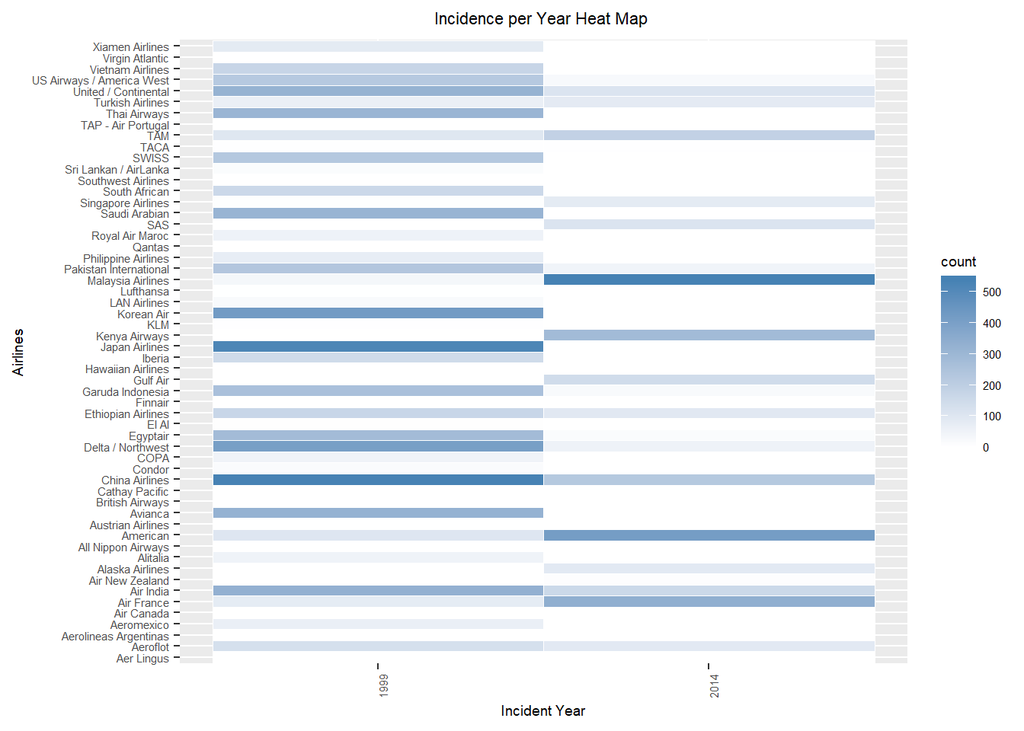

```r
ggplot(dsALTransformCombined, aes(incident_year, airline)) + geom_tile(aes(fill = count), colour = "white") + scale_fill_gradient(low = "white", high = "steelblue") + theme(text = element_text(size=7), axis.text.x = element_text(angle=90, hjust=1)) + ylab("Airlines") + xlab("Incident Year") + ggtitle("Incidence per Year Heat Map ") + theme(plot.title = element_text(hjust = 0.5))
```

```r
customGreen0 = "#DeF7E9"
customGreen = "#71CA97"
customRed = "#ff7f7f"

dsALTransformTable <- subset(dsALTransformCombined, select = c(airline,incident_type,incident_year,count,incident_ratio))

names(dsALTransformTable) <- c("Airlines","Incident Type","Year","Count","Ratio")

formattable(dsALTransformTable, align =c("l","c","c","c","c", "c", "c", "c", "r"), list(
  `Indicator Name` = formatter("span", style = ~ style(color = "grey",font.weight = "bold")),
  `Count`= color_tile(customGreen, customRed),
  `Ratio`= color_tile(customGreen, customRed)
))
```

| Airlines | Incident Type | Year | Count | Ratio |
| --- | --- | --- | --- | --- |
| Aer Lingus | incident | 1999 | 2 | 160 |
| Aeroflot | incident | 1999 | 76 | 16 |
| Aerolineas Argentinas | incident | 1999 | 6 | 64 |
| Aeromexico | incident | 1999 | 3 | 199 |
| Air Canada | incident | 1999 | 2 | 933 |
| Air France | incident | 1999 | 14 | 215 |
| Air India | incident | 1999 | 2 | 435 |
| Air New Zealand | incident | 1999 | 3 | 237 |
| Alaska Airlines | incident | 1999 | 5 | 193 |
| Alitalia | incident | 1999 | 7 | 100 |
| All Nippon Airways | incident | 1999 | 3 | 614 |
| American | incident | 1999 | 21 | 249 |
| Austrian Airlines | incident | 1999 | 1 | 358 |
| Avianca | incident | 1999 | 5 | 79 |
| British Airways | incident | 1999 | 4 | 795 |
| Cathay Pacific | incident | 1999 | 0 | 2582 |
| China Airlines | incident | 1999 | 12 | 68 |
| Condor | incident | 1999 | 2 | 209 |
| COPA | incident | 1999 | 3 | 183 |
| Delta / Northwest | incident | 1999 | 24 | 272 |
| Egyptair | incident | 1999 | 8 | 70 |
| El Al | incident | 1999 | 1 | 335 |
| Ethiopian Airlines | incident | 1999 | 25 | 20 |
| Finnair | incident | 1999 | 1 | 506 |
| Garuda Indonesia | incident | 1999 | 10 | 61 |
| Gulf Air | incident | 1999 | 1 | 301 |
| Hawaiian Airlines | incident | 1999 | 0 | 494 |
| Iberia | incident | 1999 | 4 | 293 |
| Japan Airlines | incident | 1999 | 3 | 525 |
| Kenya Airways | incident | 1999 | 2 | 139 |

[output cut: 306 more lines]